# COVID-19 Dashboard: Community COVID data and disease outcomes

##Group 12: Ling Zhou, Alexis Hill, Kendra Zwonitzer Maclaine

### Introduction

COVID-19 has affected the entire globe. In the US alone, there have been almost 300,000 deaths from the severe acute respiratory syndrome coronavirus-2 (SARS-CoV-2). Experts have predicted that it will take at least until the end of 2021 for global life to return to “normal” (healthline). Though global data and concerns about COVID can be overwhelming, it is important that each person stays educated on their local COVID situation. This was the motivation behind creating our Shiny app for counties in the state of Texas. We obtained community activity data and COVID case data to create a local and accessible COVID-19 dashboard. We predicted that overall activity would show a sharp decrease at the beginning of the pandemic and then a slow increase toward normal over time. We were also interested in how COVID-19 trends appeared in urban vs. more rural Texas counties.

COVID-19 has disproportional impacts on different locations, age groups and racial groups. Learning the local distributions of and trends of the confirmed cases and death cases will get us prepared and will help inform us to take actions to protect ourselves. COVID-19 data demographic analysis can also provide guidance to resource allocation and incoming vaccine distribution.

#### Local COVID-19 Demographic Data and Plots

COVID-19 has disproportional impacts on different locations, age groups and racial groups. Learning the local distributions of and trends of the confirmed cases and death cases will get us prepared and will help inform us to take actions to protect ourselves. COVID-19 data demographic analysis can also provide guidance to resource allocation and incoming vaccine distribution.

### Overall goals

1. Learn how to use and deploy Shiny apps with interactive graphs/maps.
2. Create a COVID-19 interactive dashboard using Shiny to gain insignt into local COVID-19 trends.
3. Learn about the possibilities and limits about how publicly available COVID data can be used to help the public.

### Data Sources and computational methods

R version 4.0 was used to generate all graphs. Tidyverse was used to clean data. The app was created and deployted using Shiny. Interactive maps were made with leaflet. Interactive graphs showing county-level activity and cases were created using ggplot. The app is stored on a shiny server.

Texas county polygons were downloaded using the tigris package. Activity datasets were downloaded from google: https://www.google.com/covid19/mobility/. COVID-19 case data was taken from the NYtimes github: https://github.com/nytimes/covid-19-data.

COVID-19 college cases data source: https://github.com/nytimes/covid-19-data/tree/master/colleges. Travis county local COVID-19 cases and demographic information data was taken from Austin-Travis County COVID-19 Dashboard Public Datasets: https://experience.arcgis.com/experience/3793562ab87e4299b106e0c282bb1fc5.

### Results

#### Activity Data in Texas Counties

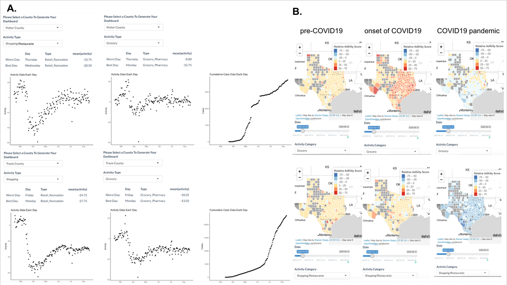

Overall, most counties’ activity trend fowllowed a similar pattern. Activity dropped during the first few weeks of the pandemic and then increased. More urban and populated counties tended not to return to normal activity levels after the drop, while less populated counties tended to see activity return to normal levels, especially in the grocery category (Figure 1A). An example of this is shown in figure 1A, comparing Travis county, which is more urban, to Potter county, which is more rural.

Each day of the week was averaged over the last 4 weeks in the dataset. Friday showed the higheset activity score and Monday showed the lowest in grocery and shopping categories in Travis county. In Potter county, Thursday had the highest activity score in both counties, while Wednesday and Monday had the lowest activity scores for shopping and grocery respectively (Figure 1A).

**Local COVID-19 Demographic and County-level Plots**

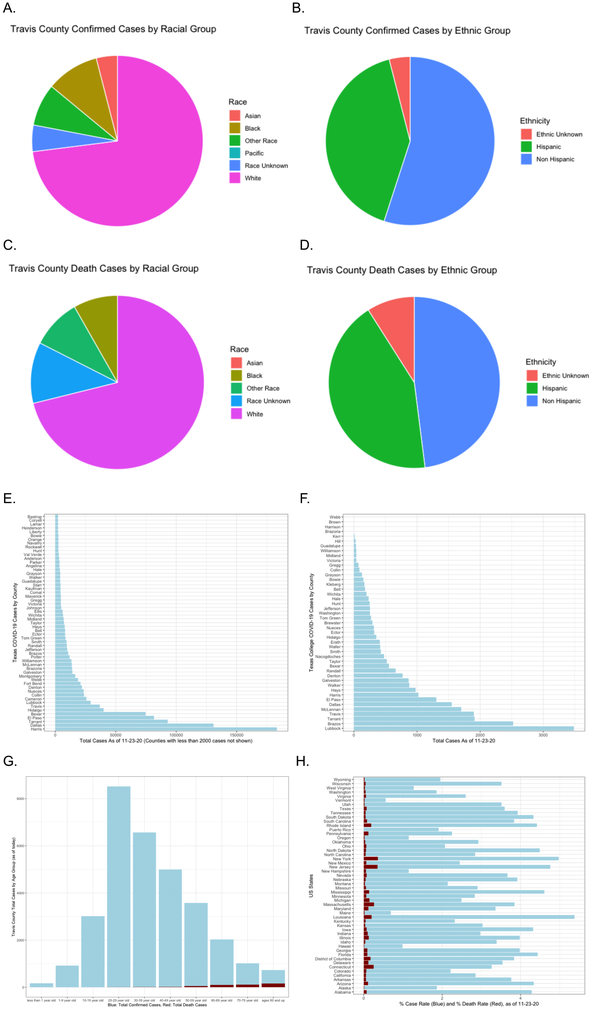

Figure 2. Local COVID Plots

Within Texas, Harris county, Dallas county and Tarrant have the highest number of confirmed cases by the end of November, and Travis county has the 7th highest number of cases within Texas (Figure 2E).

We also looked at the Texas confirmed case distributions within colleges and universities by county, and our analysis shows that Lubbock county, Brazos county and Tarrant county have the highest numbers of cases from colleges and universities. Travis county has the 4th highest number of cases reported from local colleges and universities (Figure 2F).

To take a closer look at the demographic information of the confirmed and death cases within Travis county, we analyzed data from Austin-Travis County COVID-19 Dashboard Public Datasets available online and plotted the distributions of total confirmed and death cases by age group. Based on our analysis, by the end of November, the highest number of cases falls into the younger population age between 20 to 39, but very low amount of death cases was reported within these age groups. Unlike the younger generations with relatively less pre-existing health conditions, people over 50 years old has much higher death rates as their age increases, with the group “ages 80 and up” being hit the most strongly by COVID-19 (Figure 2G).

Non-Hispanics group has slightly higher proportion of confirmed cases compared to Hispanics, and the death case proportions are relatively equal among the two groups (Figure 2B, 2D).

With all the information above, we saw that the younger generations are the main group who’s contracting and potentially spreading the disease, but the aged groups are the ones who are dying from it. Racial- and ethnic-wise, the white population are the largest population who are contracting the disease, and the proportion is close to the proportion of the White population (70.8%, Austin, TX Census Place, https://datausa.io) in Austin. Data analysis limitations in this section includes 1) the Texas college total cases analysis may be biased towards the universities that are rigorously testing and reporting the cases as there is no state-wise standards for testing and reporting among colleges and universities, and 2) it is difficult to give statistical significance conclusions on the case distribution analysis as there are no duplicates available for standard error calculation for case reporting.

### Conclusions

Different Texas communities showed different activity patterns during COVID-19. Urban counties in Texas seemed to be less likely to have their activity scores return to normal after the initial drop in activity, while less populated counties tended to show a better recovery in community activity.

Grocery stores showed a huge spike in activity at the onset of the pandemic, while other retail stores did not have this spike.

### Author Contributions

Kendra: Learned and set-up the shiny app, deployed the app on the shiny server, made the gif on the front page, and made the interactive plots on the “COVID-19 Dashboard: State and County” tab. Wrote the results for my plots, contributed to abstrct and introduction.

https://www.healthline.com/health-news/fauci-and-other-experts-debate-when-our-covid-19-lives-will-return-to-normal#3

**Local COVID Plots** Figures are in shiny app tab order

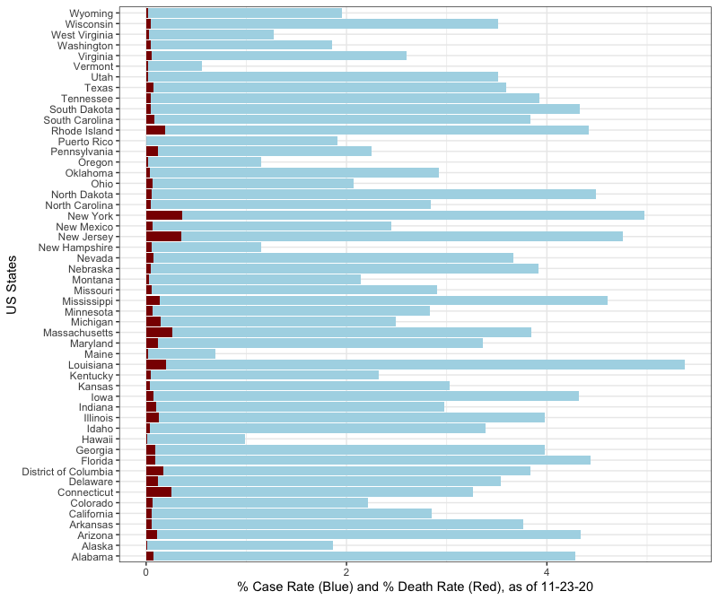

Figure 8. US Cases Confirmed vs Death by State

Within Texas, Harris county, Dallas county and Tarrant have the highest number of confirmed cases by the end of November, and Travis county has the 7th highest number of cases within Texas (Figure 5).

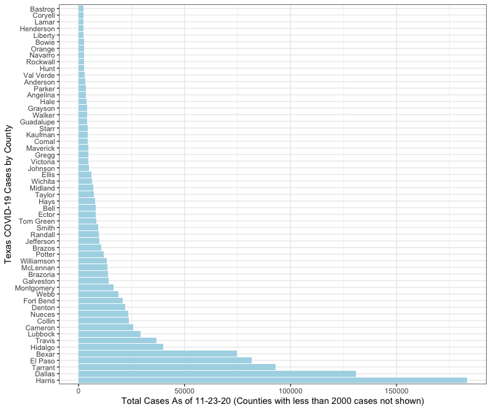

Figure 5. Texas Covid Cases by County

We also looked at the Texas confirmed case distributions within colleges and universities by county, and our analysis shows that Lubbock county, Brazos county and Tarrant county have the highest numbers of cases from colleges and universities. Travis county has the 4th highest number of cases reported from local colleges and universities (Figure 6).

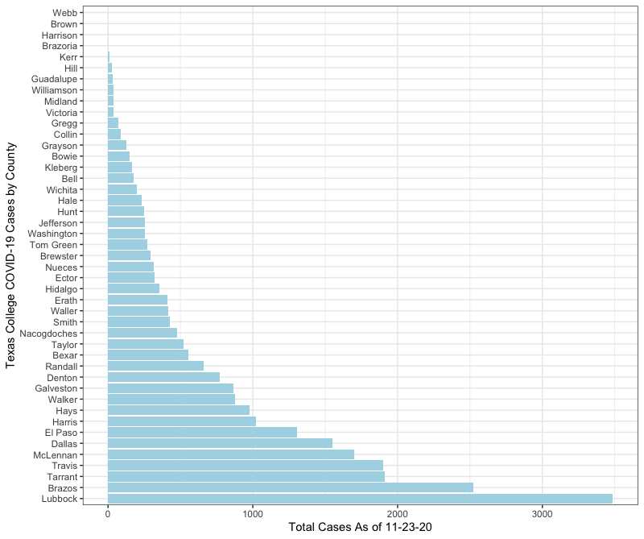

Figure 6. Texas College Total Cases by County

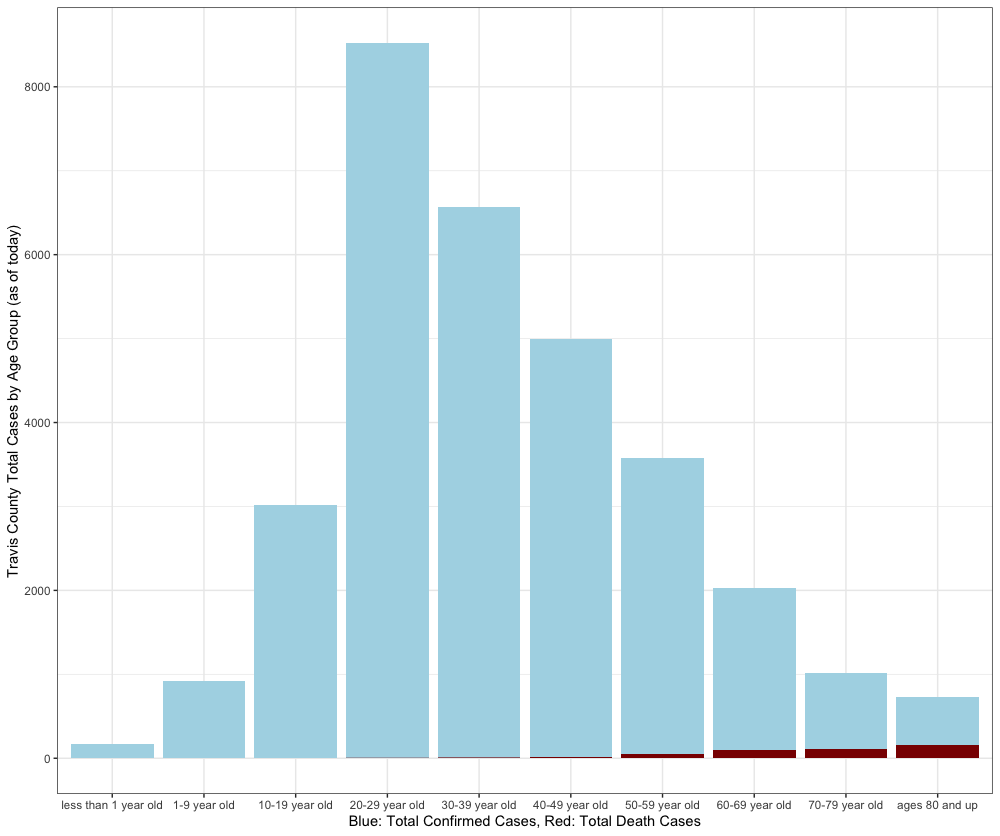

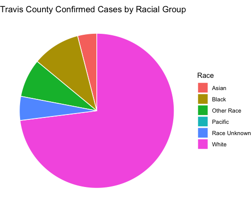

Figure 1. Travis County Confirmed Cases by Racial Group

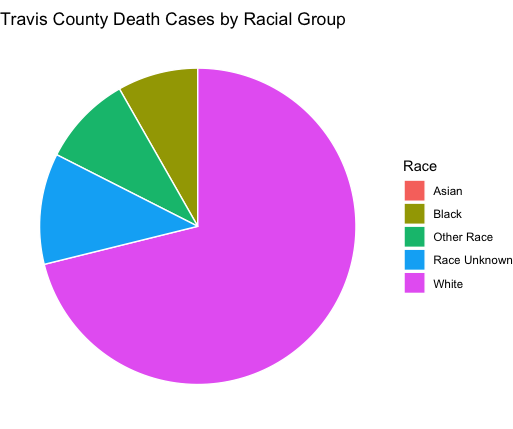

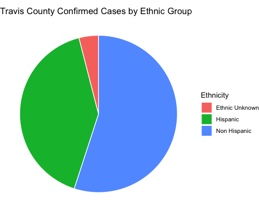

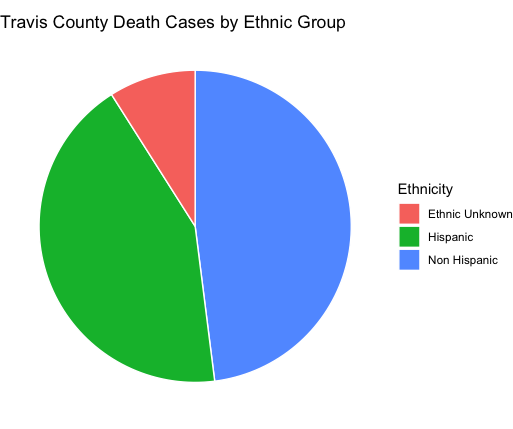

With all the information above, we saw that the younger generations are the main group who’s contracting and potentially spreading the disease, but the aged groups are the ones who are dying from it. Racial- and ethnic-wise, the white population are the largest population who are contracting the disease, and the proportion is close to the proportion of the White population (70.8%, Austin, TX Census Place, https://datausa.io) in Austin. Data analysis limitations in this section includes 1) the Texas college total cases analysis may be biased towards the universities that are rigorously testing and reporting the cases as there is no state-wise standards for testing and reporting among colleges and universities, and 2) it is difficult to give statistical significance conclusions on the case distribution analysis as there are no duplicates available for standard error calculation for case reporting.

https://www.healthline.com/health-news/fauci-and-other-experts-debate-when-our-covid-19-lives-will-return-to-normal#3